# STAT2401 Analysis of Experiments

Practical Week 8: Solutions

## Learning Check

When you complete this session, you will be able to:

1. understand how to perform ANOVA in the Multiple Linear Regression (MLR);
2. understand how to perform Partial F-Test in the Multiple Linear Regression (MLR);
3. understand how to perform diagnostics in Multiple Linear Regression modelling using R;
4. understand how to perform regression modelling with categorical variables.

```r
print(load("STAT1000_Data_Week8.RData"))
```

```
[1] "Defects"         "ChangeoverTimes" "Girth"
```

## Question 1 ANOVA - Concept

Complete the ANOVA table below. There are $n = 26$ observations, and $p = 2$ explanatory variables have been fitted. What are the null and alternative hypotheses that are assessed by this ANOVA?

A general ANOVA table for MLR:

| Source | df | SS | MS | F |
| --- | --- | --- | --- | --- |
| Regression | p | SSR | SSR/p=MSR | MSR/MSE |
| Residual | n-p-1 | SSE | SSE/(n-p-1)=MSE |  |
| Total | n-1 | SST |  |  |

| Source | df | SS | MS | F |
| --- | --- | --- | --- | --- |
| Regression | *2* | *1200* | 600 | *14.1* |
| Residual | *23* | *980* | *42.6* |  |
| Total | *25* | 2180 |  |  |

The F statistic seen in this ANOVA is used to assess the hypothesis that none of the considered explanatory variables are useful in explaining the mean response of the dependent variable.

The sampling distribution is: $F_df{2,23}$.

The p-value is: $p-value=P(F_{2,23} > 14.1).$

More formally:
$$H_0: \beta_1=\beta_2=0
{\rm \ against \ H_A: \ at \ least \ one \ of} \ \beta_i \neq 0,
i=1,2$$

```r
pval=pf(14.1,2,23,lower.tail=FALSE)
pval
```

```
[1] 0.0001007548
```

## Question 2 Property.csv

```
 - y:  Sale price of the house/1000;
 - x1: Taxes (local, school, county)/1000;
 - x2: Number of baths;
 - x3: & Lot size (sq ft $\times$ 1000);
 - x4: Living space (sq ft $\times$ 1000);
 - x5: Number of garage stalls;
 - x6: Number of rooms;
 - x7: Number of bedrooms;
 - x8: Age of the home (years);
 - x9: Number of fireplaces.
```

1. Fit a multiple regression model relating selling price to all nine regressors. Present the fitted model.

```r
Property = read.csv("Property.csv",header=TRUE)
```

Fit the regression model and present the output.

```r
M2 = lm(y~x1+x2+x3+x4+x5+x6+x7+x8+x9,data=Property)
summary(M2)
```

```
Call:
lm(formula = y ~ x1 + x2 + x3 + x4 + x5 + x6 + x7 + x8 + x9,
    data = Property)

Residuals:
   Min     1Q Median     3Q    Max
-3.720 -1.956 -0.045  1.627  4.253

Coefficients:
            Estimate Std. Error t value Pr(>|t|)
(Intercept) 14.92765    5.91285   2.525   0.0243 *
x1           1.92472    1.02990   1.869   0.0827 .
x2           7.00053    4.30037   1.628   0.1258
x3           0.14918    0.49039   0.304   0.7654
x4           2.72281    4.35955   0.625   0.5423
x5           2.00668    1.37351   1.461   0.1661
x6          -0.41012    2.37854  -0.172   0.8656
x7          -1.40324    3.39554  -0.413   0.6857
x8          -0.03715    0.06672  -0.557   0.5865
x9           1.55945    1.93750   0.805   0.4343
---
Signif. codes:  0 '***' 0.001 '**' 0.01 '*' 0.05 '.' 0.1 ' ' 1

Residual standard error: 2.949 on 14 degrees of freedom
Multiple R-squared:  0.8531,    Adjusted R-squared:  0.7587
F-statistic: 9.037 on 9 and 14 DF,  p-value: 0.000185
```

$$\texttt{y} = \beta_0
+ \beta_1 \texttt{x1}
+ \beta_2 \texttt{x2}
+ \beta_3 \texttt{x3}
+ \beta_4 \texttt{x4}
+ \beta_5 \texttt{x5}
+ \beta_6 \texttt{x6}
+ \beta_7 \texttt{x7}
+ \beta_8 \texttt{x8}
+ \beta_9 \texttt{x9}
+ \epsilon$$
where $\epsilon$ is a normal random variable.

So the fitted line is
$$\widehat{\texttt{y}} =
14.92765
+ 1.92472 \texttt{x1}
+ 7.00053 \texttt{x2}
+ 0.14918 \texttt{x3}
+ 2.72281 \texttt{x4}
+ 2.00668 \texttt{x5}
- 0.41012 \texttt{x6}
- 1.40324 \texttt{x7}
- 0.03715 \texttt{x8}
+ 1.55945 \texttt{x9}$$

2. Test for significance of regression at the level of 5%. What conclusions can you draw?

To test H$_0:\beta_1=\beta_2=\beta_3=\beta_4=\beta_5=\beta_6=\beta_7=\beta_8=\beta_9=0$ vs H$_1:$ Not H$_0$, we can look the $p$-value from the output. the $p$-value is 0.000185 $<0.05=\alpha$, so the model is statistically significant at the level 5%.

3. What is the contribution of lot size (x3) and living space (x4) to the model given that all of the other regressors are included?

We are interested in the test H$_0:\beta_3=\beta_4=0$ vs H$_1:$ Not H$_0$. We apply the R-code

```r
M2 = lm(y~x1+x2+x3+x4+x5+x6+x7+x8+x9,data=Property)
M3 = lm(y~x1+x2+x5+x6+x7+x8+x9,data=Property)
anova(M3,M2)
```

```
Analysis of Variance Table

Model 1: y ~ x1 + x2 + x5 + x6 + x7 + x8 + x9
Model 2: y ~ x1 + x2 + x3 + x4 + x5 + x6 + x7 + x8 + x9
  Res.Df    RSS Df Sum of Sq      F Pr(>F)
1     16 127.36
2     14 121.75  2    5.6083 0.3225 0.7296
```

## Question 3 Adapted from Sheather (2009) Chapter 5: Menu pricing in a new Italian restaurant in New York City

The aim of this scenario is to produce a regression model to predict the price of dinner using data from surveys of customers of 168 Italian restaurants in the target area are available.

The data are in the form of the average of customer views on:

- Y = Price = the price (in $US) of dinner (including 1 drink & a tip)
- X1= Food = customer rating of the food (out of 30)
- X2= Décor = customer rating of the decor (out of 30)
- X3= Service = customer rating of the service (out of 30)
- X4= East = dummy variable = 1 (0) if the restaurant is east (west) of Fifth Avenue

The data are given on the book web site in the file *nyc.csv*.

1. Recall the fitted model that being produced last week. Use all of the four variables.

```r
nyc=read.csv("nyc.csv")
head(nyc)
```

```
  Case          Restaurant Price Food Decor Service East
1    1 Daniella Ristorante    43   22    18      20    0
2    2  Tello's Ristorante    32   20    19      19    0
3    3          Biricchino    34   21    13      18    0
4    4             Bottino    41   20    20      17    0
5    5          Da Umberto    54   24    19      21    0
6    6            Le Madri    52   22    22      21    0
```

```r
nyc1=nyc[,c(-1,-2,-7)]  ## nyc1 consists of all numerical data
View(nyc1)
```

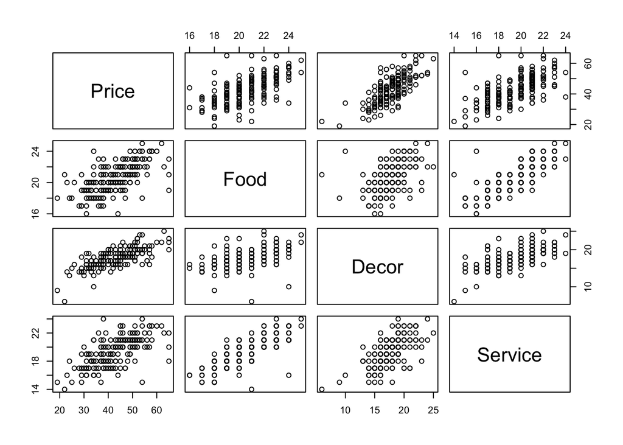

```r
# Scatterplot
pairs(nyc1)
library(PerformanceAnalytics)  ## install this
```

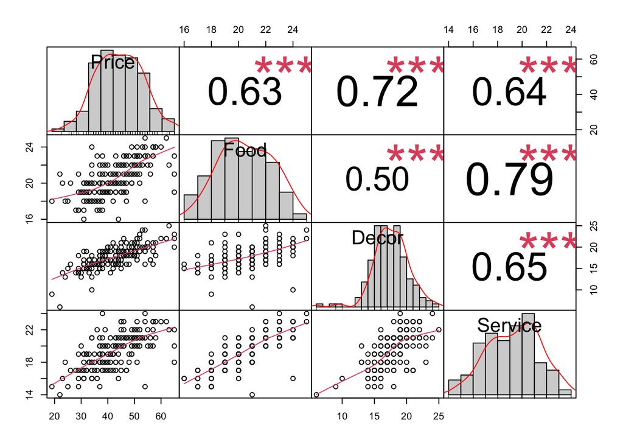

```r
chart.Correlation(nyc1)
```

```r
nyc2=nyc[,c(-1,-2)] # excluding case and restaurant columns
ny.lm=lm(Price~.,data=nyc2)  ## full model
summary(ny.lm)
```

```
Call:
lm(formula = Price ~ ., data = nyc2)

Residuals:
     Min       1Q   Median       3Q      Max
-14.0465  -3.8837   0.0373   3.3942  17.7491

Coefficients:
              Estimate Std. Error t value Pr(>|t|)
(Intercept) -24.023800   4.708359  -5.102 9.24e-07 ***
Food          1.538120   0.368951   4.169 4.96e-05 ***
Decor         1.910087   0.217005   8.802 1.87e-15 ***
Service      -0.002727   0.396232  -0.007   0.9945
East          2.068050   0.946739   2.184   0.0304 *
---
Signif. codes:  0 '***' 0.001 '**' 0.01 '*' 0.05 '.' 0.1 ' ' 1

Residual standard error: 5.738 on 163 degrees of freedom
Multiple R-squared:  0.6279,    Adjusted R-squared:  0.6187
F-statistic: 68.76 on 4 and 163 DF,  p-value: < 2.2e-16
```

The initial regression model is

*Price = – 24.02 + 1.54 Food + 1.91 Decor – 0.003 Service + 2.07 East*

At this point we shall leave the variable Service in the model even though its regression coefficient is not statistically significant.

2. Conduct the ANOVA F Test (6 steps) for the full model with all 4 variables.

```r
anova(ny.lm)
```

```
Analysis of Variance Table

Response: Price
           Df Sum Sq Mean Sq  F value  Pr(>F)
Food        1 5670.3  5670.3 172.2269 < 2e-16 ***
Decor       1 3223.7  3223.7  97.9142 < 2e-16 ***
Service     1    3.9     3.9   0.1192 0.73037
East        1  157.1   157.1   4.7716 0.03036 *
Residuals 163 5366.5    32.9
---
Signif. codes:  0 '***' 0.001 '**' 0.01 '*' 0.05 '.' 0.1 ' ' 1
```

```r
str(anova(ny.lm))
```

```
Classes 'anova' and 'data.frame':   5 obs. of  5 variables:
 $ Df     : int  1 1 1 1 163
 $ Sum Sq : num  5670.3 3223.67 3.92 157.1 5366.52
 $ Mean Sq: num  5670.3 3223.67 3.92 157.1 32.92
 $ F value: num  172.227 97.914 0.119 4.772 NA
 $ Pr(>F) : num  2.60e-27 2.25e-18 7.30e-01 3.04e-02 NA
 - attr(*, "heading")= chr [1:2] "Analysis of Variance Table\n" "Response: Price"
```

We would like to obtain *Regression* as part of the table.

```r
ny.lmm=lm(Price~1,data=nyc2)  ## model with intercept only
anova(ny.lmm, ny.lm)
```

```
Analysis of Variance Table

Model 1: Price ~ 1
Model 2: Price ~ Food + Decor + Service + East
  Res.Df     RSS Df Sum of Sq      F    Pr(>F)
1    167 14421.5
2    163  5366.5  4      9055 68.758 < 2.2e-16 ***
---
Signif. codes:  0 '***' 0.001 '**' 0.01 '*' 0.05 '.' 0.1 ' ' 1
```

From the above, n=168, p=4; SSR= 9055; F=68.76; p-val < 2.2e-16.

(OPTIONAL) Another way to obtain the ANOVA table, using a different method, OLS (Ordinary Least Squares)

```r
library(rms)
anova(rms::ols(Price~Food+Decor+Service+East,data=nyc2))
```

```
                Analysis of Variance          Response: Price

 Factor     d.f. Partial SS   MS           F     P
 Food         1  5.721999e+02 5.721999e+02 17.38 <.0001
 Decor        1  2.550785e+03 2.550785e+03 77.48 <.0001
 Service      1  1.560020e-03 1.560020e-03  0.00 0.9945
 East         1  1.570967e+02 1.570967e+02  4.77 0.0304
 REGRESSION   4  9.054996e+03 2.263749e+03 68.76 <.0001
 ERROR      163  5.366522e+03 3.292345e+01
```

*6 steps ANOVA hypothesis testing:*

Step 1. $H_0: \beta_1=\beta_2 =\beta_3 = \beta_4 =0, H_1: at \ least \ one \ \beta_j \not= 0, j=1,2,3,4.$

Step 2. Test statistic: F=68.76

Step 3. The sampling distribution is $F_{p,n-p-1}=F_{4,163},$ as $p=4, n=168.$

Step 4. p-value < 2.2e-16.

Steps 5 and 6. We reject the null hypothesis.There is a relationship between Price and at least one of the four variables.

3. Conduct the partial F Test for
   $$H_0:
   Price_i= \beta_0+\beta_1 Food_{i} +\beta_2 Decor_{i}+\beta_3
   East_{i}$$

against
$$H_a: Price_i= \beta_0+\beta_1
Food_{i} +\beta_2 Decor_{i}+\beta_3 East_{i}+\beta_4
Service_i$$

```r
ny1.lm=lm(Price~Food+Decor+East,data=nyc2)
anova(ny1.lm,ny.lm)  ##
```

```
Analysis of Variance Table

Model 1: Price ~ Food + Decor + East
Model 2: Price ~ Food + Decor + Service + East
  Res.Df    RSS Df Sum of Sq  F Pr(>F)
1    164 5366.5
2    163 5366.5  1   0.00156  0 0.9945
```

*6 steps hypothesis testing: Partial F Test*

Step 1. $H_0: Price_i= \beta_0+\beta_1 Food_{i} +\beta_2 Decor_{i}+\beta_3 East_{i}, H_a: Price_i= \beta_0+\beta_1 Food_{i} +\beta_2 Decor_{i}+\beta_3 East_{i}+\beta_4 Service_i$

Step 2. Test statistic: F= 0

Step 3. The sampling distribution is $F_{c, n-q-c}=F_{1,163},$ as $q=4,c=1, n=168.$

Step 4. p-value=0.9945.

Steps 5 and 6. We do not reject the null hypothesis. The variable Service should not be added in the model.

4. Perform diagnostics checking of the model in (a) using residual analysis.

Recall from Week 9 Comp Lab.

According to Sheather (2009):

- for small to moderate sample sizes, points are considered as *outliers* if the standardized residual for the point falls outside the interval from –2 to 2 .
- for very large data sets, this rule may change to –4 to 4 based on standardised residuals.
- a *bad leverage point* is a leverage point (if leverage $h_{ii} > 2(p+1)/ n$) which is also an outlier. Thus, a bad leverage point is a leverage point whose standardized residual falls outside the interval from –2 to 2.
- On the other hand, a *good leverage point* is a leverage point whose standardized residual falls inside the interval from –2 to 2 .

Firstly, we calculate standardised residuals.

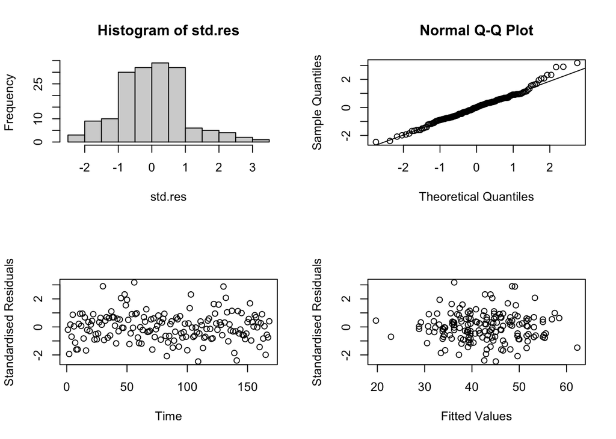

```r
res=ny.lm$residuals
std.res=rstandard(ny.lm)  ## standardised residuals
par(mfrow=c(2,2))  ## plotting 4 plots to check normality and constant variance
hist(std.res)
qqnorm(std.res)
qqline(std.res)
plot(std.res,xlab="Time", ylab="Standardised Residuals")
plot(ny.lm$fitted.values,std.res, xlab="Fitted Values", ylab="Standardised Residuals")
```

```r
par(mfrow=c(1,1))
```

Plot of standardised residuals against each of explanatory variables.

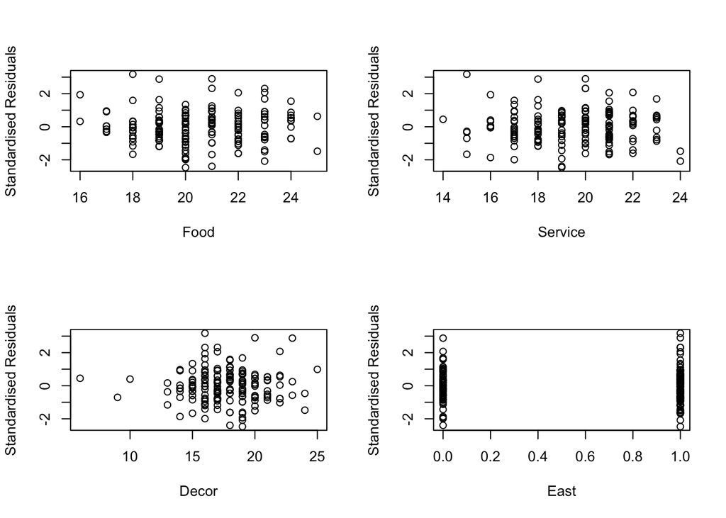

```r
par(mfrow=c(2,2))
plot(nyc$Food,std.res,xlab="Food", ylab="Standardised Residuals")
plot(nyc$Service,std.res,xlab="Service", ylab="Standardised Residuals")
plot(nyc$Decor,std.res,xlab="Decor", ylab="Standardised Residuals")
plot(nyc$East,std.res,xlab="East", ylab="Standardised Residuals")
```

5. Identify outliers if any.

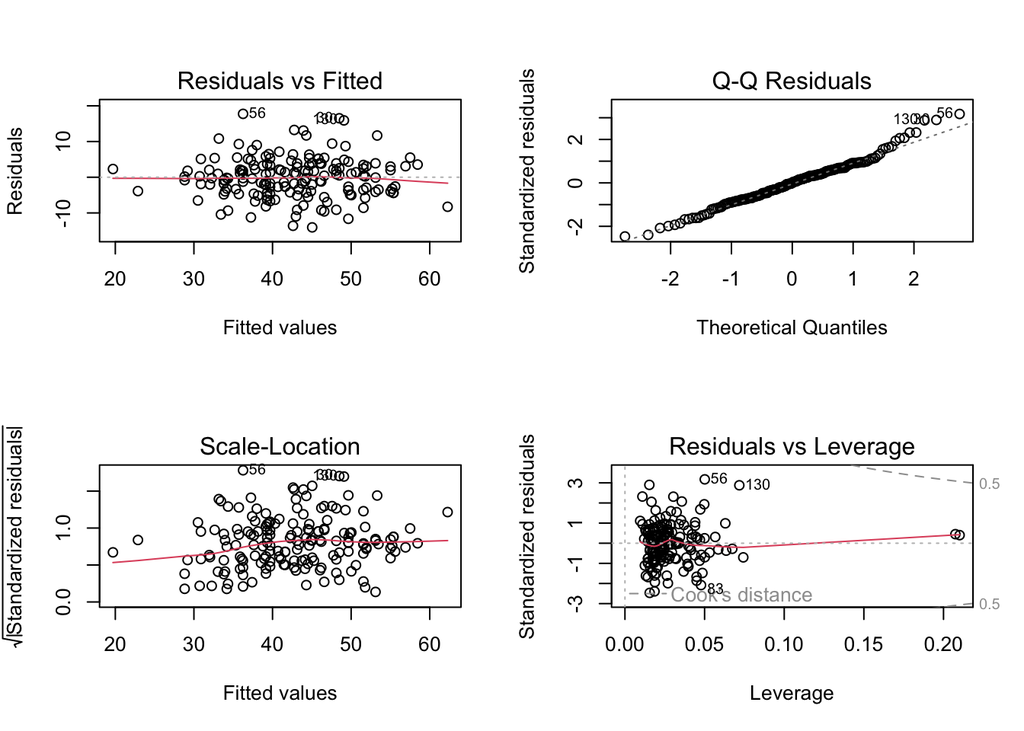

```r
par(mfrow=c(2,2))
plot(ny.lm)
```

The only concern is about the plot of standardised residuals against Leverage.

```r
Leverage<-hatvalues(ny.lm)
head(Leverage)
```

```
         1          2          3          4          5          6
0.02259993 0.01878696 0.04705254 0.05012365 0.04397242 0.03260207
```

```r
Cooks.Dist<-cooks.distance(ny.lm)
head(Cooks.Dist)
```

```
           1            2            3            4            5            6
0.0001873746 0.0142868114 0.0002788518 0.0051170466 0.0069443574 0.0000102911
```

The cut-off for Leverage is $2*(p+1)/n$ and for Cooks’ Distance is $2*(p+1)/(n-(p+1)).$

For p=4, n=168, 0.0595 and 0.0613 are the cut-off for Leverage and Cook respectively.

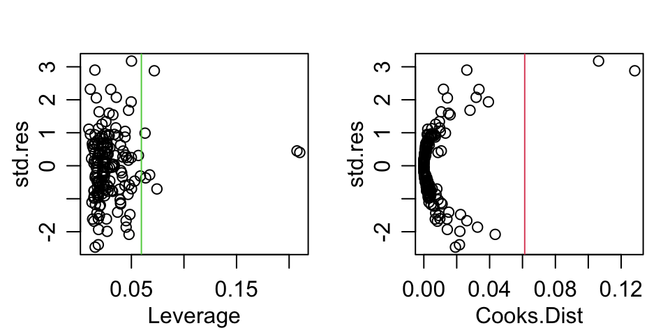

```r
# plotting the std res against the influence measures
p=4
n=168
par(mfrow=c(1,2))
par(mgp=c(1.75,0.75,0))
par(mar=c(3,3,2,1))
plot(std.res~Leverage)
abline(v=2*(p+1)/n, lty=1,col=3)  ## add a vertical line for the cut-off Leverage
plot(std.res~Cooks.Dist)
abline(v=2*(p+1)/(n-(p+1)), lty=1, col=2)  ## add a vertical line for the cut-off Cooks
```

Leverage identifies a couple outliers.

Definitely there are 2 influential points identified by Cook’s Distance.

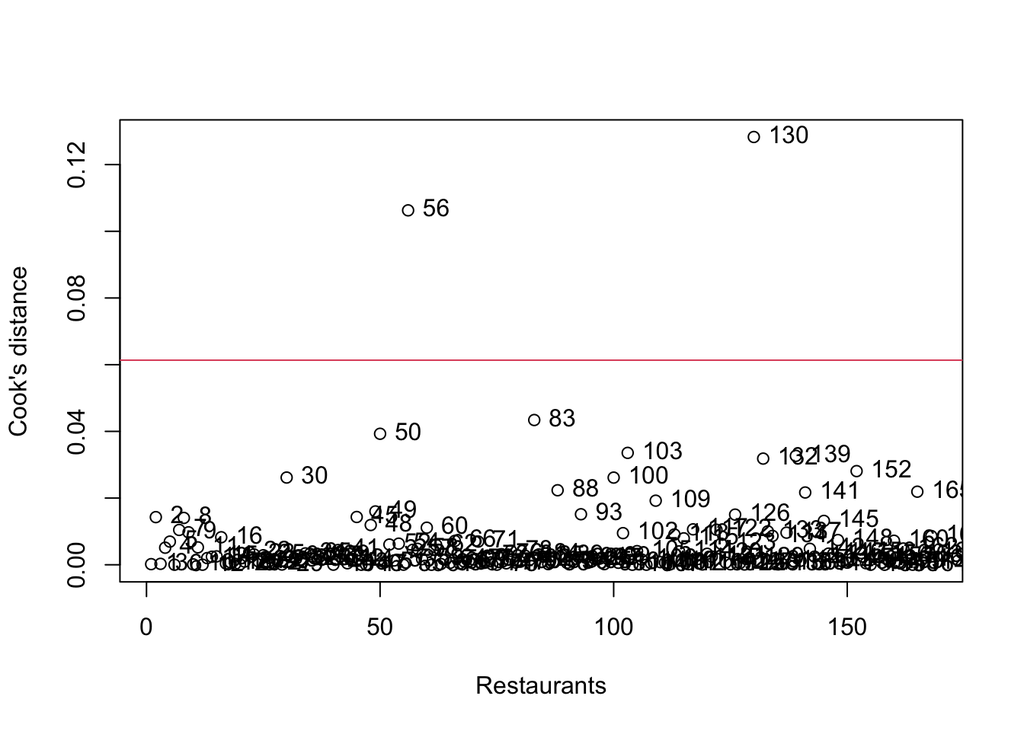

```r
plot(cooks.distance(ny.lm), xlab = "Restaurants", ylab = "Cook's distance")
abline(h=2*(p+1)/(n-(p+1)), lty=1, col=2)
with(nyc, text(cooks.distance(ny.lm), labels = row.names(nyc), pos = 4))
```

```r
# Can only do the next step interactively in the console
# identify(1:168, cooks.distance(ny.lm),label=rownames(nyc))
```

```r
# Detecting outliers in the dataset
di=2*(p+1)/(n-(p+1))  ## cut-off
# Defining outliers based on 2*(p+1)/(n-(p+1)) criteria
nyc$outlier <- ifelse(Cooks.Dist < di, "keep","delete")
View(nyc)
```

- OPTIONAL (Added Variable Plot)

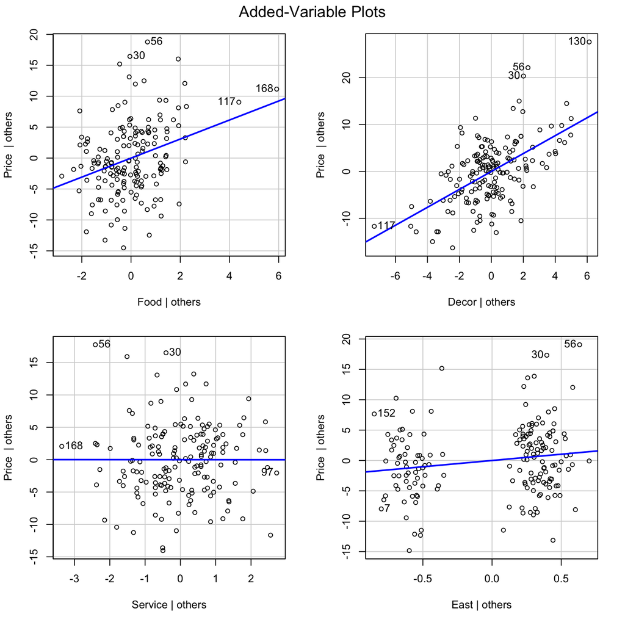

```r
nyc <- read.csv("nyc.csv", header=TRUE)
avPlots(lm(Price~Food+Decor+Service+East, data=nyc))
```

```r
#avPlot(m1,variable=Food,ask=FALSE,identify.points=TRUE)
# Click on the points you wish to identify. When you wish
# to stop click the right mouse button and select "Stop"
#avp(m1,variable=Decor,ask=FALSE,identify.points=FALSE)
#avp(m1,variable=Service,ask=FALSE,identify.points=FALSE)
#avp(m1,variable=East,ask=FALSE,identify.points=FALSE)
```

## Question 4 - fitting linear models with a single categorical explanatory variable

The data frame `ChangeoverTimes` contains data on two different methods for switching an industrial process over from one type of product to another. The two different methods are an existing one and a new one, and there are two additional variables (`Method` and `New`) in the data frame that designate the different methods.

```r
head(ChangeoverTimes)
```

```
    Method Changeover New
1 Existing         19   0
2 Existing         24   0
3 Existing         39   0
4 Existing         12   0
5 Existing         29   0
6 Existing         19   0
```

```r
View(ChangeoverTimes)
```

Note that the column “New” is just a 0-1 indicator column corresponding to Method being “Existing” (0) or “New” (1).

1. Produce a boxplot of the changeover times for each of the methods.

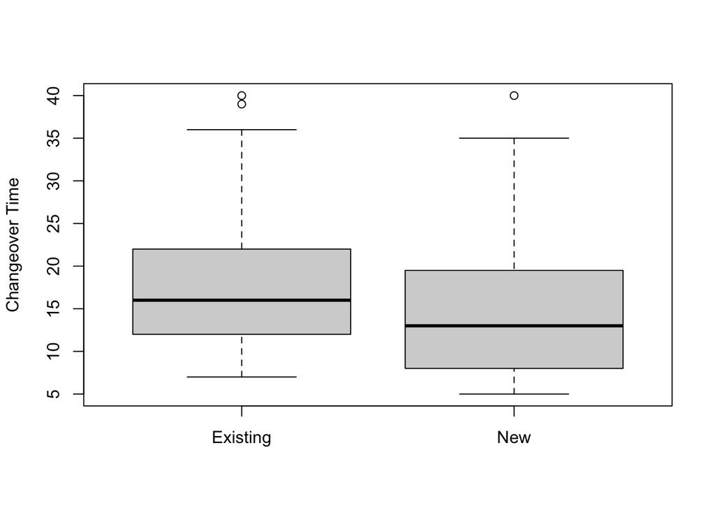

```r
# Boxplot
boxplot(split(ChangeoverTimes$Changeover,ChangeoverTimes$Method), ylab="Changeover Time")
```

While we can use a t-test to assess if the mean changeover times differ according to method, we will first do this via linear regression.

2. Write out and fit a linear regression model relating changeover time to changeover method. You can use either of the variables `Method` or `New` (look at them first). What is the mean for each of the different methods?

The model can be written as

$$y = \beta_0 + \beta_1 z +
\epsilon\,$$

where $z$ is an indicator variable that takes on a value of zero for the existing method and one for the new method. The expected value for each methods is as follows:

$$E(y | z = 0) = \beta_0, \quad E(y | z =
1) = \beta_0 + \beta_1$$

```r
ChangeoverTimes
```

```
      Method Changeover New
1   Existing         19   0
2   Existing         24   0
3   Existing         39   0
4   Existing         12   0
5   Existing         29   0
6   Existing         19   0
7   Existing         23   0
8   Existing         22   0
9   Existing         12   0
10  Existing         29   0
11  Existing         22   0
12  Existing         23   0
13  Existing         12   0
14  Existing         40   0
```

[output cut: 106 more lines]

```r
# Linear model with categorical explanatory variable
fit<-lm(Changeover~Method,data=ChangeoverTimes)
summary(fit)
```

```
Call:
lm(formula = Changeover ~ Method, data = ChangeoverTimes)

Residuals:
    Min      1Q  Median      3Q     Max
-10.861  -5.861  -1.861   4.312  25.312

Coefficients:
            Estimate Std. Error t value Pr(>|t|)
(Intercept)  17.8611     0.8905  20.058   <2e-16 ***
MethodNew    -3.1736     1.4080  -2.254    0.026 *
---
Signif. codes:  0 '***' 0.001 '**' 0.01 '*' 0.05 '.' 0.1 ' ' 1

Residual standard error: 7.556 on 118 degrees of freedom
Multiple R-squared:  0.04128,   Adjusted R-squared:  0.03315
F-statistic: 5.081 on 1 and 118 DF,  p-value: 0.02604
```

```r
# Linear model with numerical indicator as explanatory variable
fit<-lm(Changeover~New,data=ChangeoverTimes)
summary(fit)
```

```
Call:
lm(formula = Changeover ~ New, data = ChangeoverTimes)

Residuals:
    Min      1Q  Median      3Q     Max
-10.861  -5.861  -1.861   4.312  25.312

Coefficients:
            Estimate Std. Error t value Pr(>|t|)
(Intercept)  17.8611     0.8905  20.058   <2e-16 ***
New          -3.1736     1.4080  -2.254    0.026 *
---
Signif. codes:  0 '***' 0.001 '**' 0.01 '*' 0.05 '.' 0.1 ' ' 1

Residual standard error: 7.556 on 118 degrees of freedom
Multiple R-squared:  0.04128,   Adjusted R-squared:  0.03315
F-statistic: 5.081 on 1 and 118 DF,  p-value: 0.02604
```

Answer: For the existing method the mean changeover time is estimated to be 17.86 seconds (?), ie just the model intercept, whereas the mean changeover time for the new method is the sum of the 2 coefficients: 17.86 - 3.17 =14.68 seconds.

3. From the fitted model calculate a $95\%$ confidence interval for the coefficient relevant to the new method. (You can use `confint`.) How would you interpret this?

```r
# confidence interval for the x variable
confint(fit)["New",]
```

```
     2.5 %     97.5 %
-5.9617761 -0.3854461
```

Answer: We are 95% confident that the difference in the 2 means lies between -5.96 and -0.39 seconds, or we could interpret this as: the mean changeover time of the new method is between 0.39 and 5.96 seconds less than that of the existing method.

4. Using `t.test`, **and assuming equal variances**, conduct a two-sample $t$-test and calculate a $95\%$ confidence interval for the difference between the mean changeover times. What do you note?

```r
# Two-sample test with equal variances
t.test(Changeover~Method,data=ChangeoverTimes,var.equal=T)
```

```
    Two Sample t-test

data:  Changeover by Method
t = 2.254, df = 118, p-value = 0.02604
alternative hypothesis: true difference in means between group Existing and group New is not equal to 0
95 percent confidence interval:
 0.3854461 5.9617761
sample estimates:
mean in group Existing      mean in group New
              17.86111               14.68750
```

```r
#
```

The $t$-test calculates the difference (existing - new), whereas the ‘slope’ in the regression model represents (new - old), which is why one is the negative of the other, but both give the same result (when we specify that both samples have equal variances).

*NOTES.*

To create the *New* column, you can do it this way:

```r
ChangeoverTimes$New<-ifelse(ChangeoverTimes$Method=="Existing","0","1")
head(ChangeoverTimes)
```

```
    Method Changeover New
1 Existing         19   0
2 Existing         24   0
3 Existing         39   0
4 Existing         12   0
5 Existing         29   0
6 Existing         19   0
```

To make *New* as a factor:

```r
ChangeoverTimes$New<-factor(ChangeoverTimes$New)
head(ChangeoverTimes)
```

```
    Method Changeover New
1 Existing         19   0
2 Existing         24   0
3 Existing         39   0
4 Existing         12   0
5 Existing         29   0
6 Existing         19   0
```

## Question 5 UFC dataset - Outliers and Leverage

The data file `ufc.txt` gives the diameter `Dbh` in millimeters at 137 cm perpendicular to the bole, and the `Height` of the tree in decimeters for a sample of grand fir trees at Upper Flat Creek, Idaho, in 1991.

Also included in the file are the `Plot` number, the `Tree` number in a plot, and the 10 `Species` types.

```r
ufc = read.table("ufc.txt",header=T)
lm(Dbh~Height+Species,data=ufc)
```

1. Test for significance of regression using $\alpha = 0.05$. Find the $p$-value for this test. What is your conclusion?%

Read the data in and perform the regression analysis

```r
ufc = read.table("ufc.txt",header=T)
str(ufc)
```

```
'data.frame':   372 obs. of  5 variables:
 $ Plot   : int  2 2 3 3 3 4 4 4 5 5 ...
 $ Tree   : int  1 2 2 5 8 1 2 9 2 4 ...
 $ Species: chr  "DF" "WL" "GF" "WC" ...
 $ Dbh    : int  390 480 520 360 380 460 250 299 549 518 ...
 $ Height : int  205 330 300 207 225 180 170 240 293 290 ...
```

```r
M1 = lm(Dbh~Height+Species,data=ufc)
summary(M1)
```

```
Call:
lm(formula = Dbh ~ Height + Species, data = ufc)

Residuals:
    Min      1Q  Median      3Q     Max
-264.29  -65.71   -9.58   53.86  525.79

Coefficients:
              Estimate Std. Error t value Pr(>|t|)
(Intercept) -106.97096   23.66973  -4.519 8.42e-06 ***
Height         1.98366    0.07526  26.358  < 2e-16 ***
SpeciesES     16.54585   74.33521   0.223 0.823985
SpeciesGF    -23.89586   17.03974  -1.402 0.161667
SpeciesHW    -77.22042   53.60155  -1.441 0.150554
SpeciesLP    -78.79505   61.26404  -1.286 0.199213
SpeciesPP     22.36279   74.52780   0.300 0.764304
SpeciesSF    -63.21122   36.28170  -1.742 0.082319 .
SpeciesWC     30.49084   16.55010   1.842 0.066246 .
SpeciesWL    -96.97375   26.96388  -3.596 0.000368 ***
SpeciesWP    -62.52908   23.70321  -2.638 0.008701 **
---
Signif. codes:  0 '***' 0.001 '**' 0.01 '*' 0.05 '.' 0.1 ' ' 1

Residual standard error: 103.2 on 361 degrees of freedom
Multiple R-squared:  0.6855,    Adjusted R-squared:  0.6768
F-statistic:  78.7 on 10 and 361 DF,  p-value: < 2.2e-16
```

According to the output, $p$-value for the $F$-test is less than $\alpha = 0.05$. The regression is statistically significant.

2. How many bad leverage points you can identify from the data?

We need to identify the df of regression,
$$\texttt{df of Total}=n-1=372-1=371; \quad
\texttt{df of Residual}=361; \quad
\texttt{df of Regression}=371-361=10$$
So the cut off point for leverages is $2\times(10+1)/372=0.05913978$, see the plot of Standardized Residuals vs Leverages

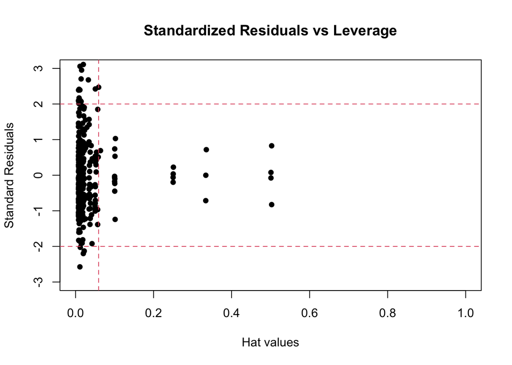

```r
plot(rstandard(M1)~hatvalues(M1),pch=16,xlim=c(0,1),ylim=c(-3,3),
     main="Standardized Residuals vs Leverage",
     xlab="Hat values",ylab="Standard Residuals")
abline(h=c(-2,2),col=c(2,2),lty=2)
abline(v=2*(10+1)/372,col=2,lty=2)
```

Find the exact high leverage points and outliers

```r
p = 10 + 1
n = 372
index.highleverage = which(hatvalues(M1)>2*p/n)
index.outlier = which(abs(rstandard(M1))>2)
```

```
      - High leverage points:
```

```r
data.frame(ufc,hatvalues=hatvalues(M1),stdres=rstandard(M1))[index.highleverage,]
```

```
    Plot Tree Species Dbh Height  hatvalues       stdres
30    12    6      SF 170    183 0.10044390 -0.233153896
34    15    1      LP 240    245 0.33371128 -0.714794499
46    18    2      SF 160    130 0.10030869  0.738450856
47    18    3      SF 115    205 0.10137697 -1.241272083
73    23    4      HW 207    200 0.25000332 -0.061978224
76    25    2      LP 192    160 0.33514185  0.717336456
80    27    4      LP 310    250 0.33386629 -0.001771662
109   37    1      SF 143    180 0.10035652 -0.448118198
111   37    4      ES 380    240 0.50085037 -0.077517345
123   41    3      ES 550    320 0.50085037  0.077517345
158   49    2      SF 150    163 0.10004210 -0.032212440
159   49    3      SF 107    143 0.10006548 -0.066184062
161   50    2      SF 191    187 0.10057528 -0.099716970
169   53    3      SF 110    150 0.10000893 -0.177336473
172   54    3      SF 100    110 0.10103363  0.531071049
182   57    5      HW 312    240 0.25074740  0.225086291
185   59    2      PP 769    400 0.50260426  0.826098616
187   59    6      HW 176    180 0.25026906  0.035044001
188   59    7      HW 175    190 0.25008304 -0.198044702
258   88    3      WL 708    425 0.06386225  0.689716984
315  113    2      SF 109     90 0.10218376  1.029020980
345  128    7      PP 371    260 0.50260426 -0.826098616
```

```
      - Outliers:
```

```r
data.frame(ufc,hatvalues=hatvalues(M1),stdres=rstandard(M1))[index.outlier,]
```

```
    Plot Tree Species  Dbh Height   hatvalues    stdres
14     6    3      WC  294    320 0.011051392 -2.574476
15     6    4      WC  685    260 0.007644435  2.389538
38    16    3      WC  895    350 0.014189872  2.704501
43    16   10      WC  830    350 0.014189872  2.070326
81    27    6      WC  686    280 0.008354902  2.014189
91    31    1      GF  296    320 0.012067216 -2.026251
99    33    6      DF  283    310 0.019825896 -2.201172
100   34    1      WL  496    230 0.050596456  2.422855
103   35    1      GF  719    320 0.012067216  2.096331
131   43    3      WC  940    360 0.015448625  2.951894
132   43    4      WC 1015    390 0.019862662  3.110101
134   43    6      DF  350    340 0.022077834 -2.130333
138   43    6      DF  350    340 0.022077834 -2.130333
141   44    3      WP 1120    385 0.042153705  5.204242
166   52    3      GF  613    250 0.009027234  2.412840
171   54    2      WC  804    320 0.011051392  2.393459
173   55    2      DF  998    420 0.032760045  2.677492
230   78    3      WP 1030    480 0.059082053  2.470107
237   81    2      GF  588    250 0.009027234  2.169563
238   81    3      WC  595    230 0.007375959  2.092759
259   89    1      GF  798    310 0.011314044  3.058432
```

```
      - Both:
```

```r
intersect(index.outlier,index.highleverage)
```

```
integer(0)
```

There is no “bad” leverage point